# Mel Schwan, Stuart Miller, Justin Howard, Paul Adams

# Lab Two: Classification & Regression

## MiniLab2 Project Requirments -

1. Data Preparation
   1. Define and prepare your class variables
   2. Describe the final dataset that is used for classification/regression (include a description of any newly formed variables you created
1. Modeling and Evaluation
   1. Choose and explain your evaluation metrics that you will use
   2. Choose the method you will use for dividing your data into training and testing splits
   3. Create three different classification/regression models
   4. Analyze the results using your chosen method of evaluation
   5. Discuss the advantages of each model for each classification task
   6. Which attributes from your analysis are most important
1. Deployment
   1. How useful is your model for interested parties?
   2. How would you measure the model's value if it was used by these parties?
   3. How would your deploy your model for interested parties?
   4. How often would your model need to be updated?
   5. What other data should be collected?

A1. Model Hyperparameter Tuning Details

[figure not shown]

# 1. Stage Three - Data Preperation (Q1)

## 1.1 Define and prepare your class variables (Q1A)

```python
#removing warnings
import warnings
warnings.simplefilter('ignore')

# Import Libraries Required.
# pydata stack
import pandas as pd
import numpy as np
from scipy import stats
import matplotlib.pyplot as plt
from mpl_toolkits.mplot3d import Axes3D
%matplotlib inline

#plotting library
import seaborn as sns

# sklearn
from sklearn.preprocessing import StandardScaler, LabelEncoder
from sklearn.model_selection import train_test_split, cross_val_score, GridSearchCV
from sklearn.decomposition import PCA
from sklearn.linear_model import LogisticRegression, LinearRegression, BayesianRidge
from sklearn.svm import SVC
from sklearn.impute import SimpleImputer
 # enabling sklearn's experimental gradient boosting machine algorithm
from sklearn.experimental import enable_hist_gradient_boosting  # noqa
from sklearn.ensemble import HistGradientBoostingClassifier, RandomForestClassifier, RandomForestRegressor
from sklearn.metrics import confusion_matrix, recall_score, precision_score, accuracy_score

# others
from imblearn.under_sampling import RandomUnderSampler, TomekLinks
from plot_decision_regions import plot_decision_regions
from sklearn.metrics import roc_curve, auc
from sklearn.base import BaseEstimator, TransformerMixin
from statsmodels.stats.outliers_influence import variance_inflation_factor
from IPython.display import IFrame
from math import log
from pandas_profiling import ProfileReport
from  time import time

# custom functions
from cleaning import (read_clean_data, impute_data, merge_bureau, merge_previous_application,
merge_POS_CASH, merge_credit_card_balance, merge_installments, downsampling_strategy, reduce_mem_usage)
from tables import classification_report

# set random seed
random_state= 1
np.random.seed(random_state)
```

## 1.0 Loading and Merging the Dataset

```
# loading data that was preprocessed using the custom read_clean_data() function,
# merged with the previously engineered newFeatures from Lab 1
data = read_clean_data()
```

```
data_bureau = merge_bureau(data)
data_prev = merge_previous_application(data_bureau)
data_POS_CASH = merge_POS_CASH(data_prev)
data_installments = merge_installments(data_POS_CASH)
data_full = merge_credit_card_balance(data_installments)
```

```
The shape application and bureau data combined: (307511, 115)
Dimensions after adding new features:  (307511, 119)
Dimensions after adding previous_application:  (307511, 282)
Dimensions after adding POS_CASH_balance:  (307511, 296)
Dimensions after adding installments:  (307511, 302)
Dimensions after adding credit_card_balance:  (307511, 329)
```

### 1.1 Data Preparation Explanation

The data from seven different tables was merged into one dataset for use in the analysis. The following list is a general set of procedures that were followed to complete the merge. The explicit code used to merge the datasets can be located in the reference file cleaning.py.

Multiple records exist with several rows for each unique record in the current application dataset, all categorical variables were one-hot encoded, then grouped by the unique identifier in the application dataset. After that, the mean of each grouping was taken to condense the features to a single float value. This method was applied to the following list of tables:

- bureau.csv
- previous_application.csv
- POS_CASH_BALANCE.csv
- installments.csv
- credit_card_balance.csv

```
data_lite = reduce_mem_usage(data_full)
```

```
Memory usage of dataframe is 735.51 MB
Memory usage after optimization is: 202.06 MB
Decreased by 72.5%
```

**Reducing the Amount of Categories**

```
data.CNT_FAM_MEMBERS.unique()
```

```
array([ 1.,  2.,  3.,  4.,  5.,  6.,  9.,  7.,  8., 10., 13., 14., 12.,
       20., 15., 16., 11.])
```

The dataset contains features, such as the number of children an applicant has, where the number of unique values are relatively high, but the percentage of the total makeup is almost imperceptable. The distributions of these high cardinality variables are heavily skewed. To address this issue, the number of numeric categories was reduced to get a more accurate interpretation of their impact on the target variable.

```
#recoding least valuable cateogries into meaningful bins

# reducing the child count feature to 3 categories
def cnt_child(series):
    if series == 0 :
        return 'No Children'
    elif 1 <= series < 5 :
        return '1-4 Children'
    else :
        return '5 or More Children'

# reducing family count feature to 4 categories
def cnt_family(series):
    if series == 1:
        return '1 Family Member'
    elif series == 2:
        return '2 Family Members'
    elif 3 >= series <= 5:
        return '3 - -5 Family Members'
    else :
        return '6 or more Family Members'

# reducing engineered feature CREDIT_ACTIVE to 4 categories
data.CREDIT_ACTIVE = data.CREDIT_ACTIVE.astype(np.uint32)

def credit_active(series):
    if series == 0:
        return 'No Accounts'
    elif 1 <= series <= 3:
        return '1-3 Accounts'
    else :
        return ' > 4 Accounts'

# reducing engineered feature LOAN_COUNT to 5 categories

def loan_count(series):
    if series == 0:
        return 'No Loans'
    elif 1 <= series <= 2:
        return '1-2 Loans'
    elif 3 <= series <= 5:
        return '3-5 Loans'
    elif 6 <= series <= 10:
        return '6-10 Loans'
    else :
        return ' > 10 Loans'
```

```python
#For ease of use, data was saved to CSV files and reloaded
X_train = pd.read_csv('X_train_final.csv')
X_test = pd.read_csv('X_test_final.csv')
y_train = pd.read_csv('y_train.txt', header = None).values.flatten()
y_test = pd.read_csv('y_test.txt', header = None).values.flatten()
```

## 1.2 Sampling strategies

**Resampling the Training Data**

Initially, the models were trained against training data that contained mostly non-defaulting instances. However, the model's performance on this initial training data was inferior, generally failing to classify any defaulting instances. The remedy to this issue was to resample the training data to balance the number of non-defaulting and defaulting instances. All the defaulting instances were retained, but the non-defaulting instances were randomly downsampled to match the number of non-defaulting instances. Resampled training data improved the performance of the models substantially when validated on the test data.

Additionally, the categroical variables were label encoded, rather than one-hot encoded.

### 1.2.2 Downsampling to achieve balance

Our metric of choice is recall, which can be improved most effectively by balancing the training set. We have used two strategies that selectively under-sample the data, but an imbalance between the number of defaulted loans and non-defaulted loans still persists. We will create a final training set that has defaults and non-defaulted loans represented equally.

```
def downsampling_strategy(X, y):
    y.columns = ['TARGET']
    X = X.copy(deep=True)
    y = y.copy(deep=True)
    y = y.to_frame(name = 'TARGET')
    random_state = 1
    # balancing the training set
    df = pd.concat([X, y], axis =1)
    defaults = df[df['TARGET'] == 1]
    nominal = df[df['TARGET'] == 0].sample(
        n = np.round(0.5 * (defaults.TARGET.size / 0.5)).astype(int), random_state = random_state)
    # join dataframes and shuffle
    df = pd.concat([defaults, nominal]).sample(frac = 1, random_state = random_state)
    return df
data_final = downsampling_strategy(X_tl, y_tl)
print('Final Data shape: ', data_final.shape,
     'Percent defaults: ', data_final[data_final['TARGET'] == 1].shape[0] / data_final.shape[0])
```

### 1.1.1 Principal Component Analysis

Our feature selection decisions prompted a review of the Principal Components to see if a more significant separation between the classes is evident. We dropped variables that seemed the least useful for this type of analysis. Next, we on-hot encoded to eliminate the duplication of categorical features that were already binary indicators.

```python
# dropping variables that were deemed the least useful for analysis
y_train = data_final.TARGET.copy()
new_df = data_final.copy().drop(['TARGET'], axis = 1)
new_df = new_df.fillna(0)
new_df.info()
```

```
<class 'pandas.core.frame.DataFrame'>
Int64Index: 33778 entries, 166872 to 134341
Columns: 326 entries, NAME_CONTRACT_TYPE to CREDIT_NAME_CONTRACT_STATUS_Signed
dtypes: float32(276), int8(50)
memory usage: 37.4 MB
```

```python
sc = StandardScaler()
sc.fit(new_df)
X_std = sc.transform(new_df)
X_std.shape
```

```
(33778, 326)
```

```python
cov_mat = np.cov(X_std.T)
eigen_vals, eigen_vecs = np.linalg.eig(cov_mat)
print('\nTop Ten Eigenvalues \n%s' % eigen_vals[0:9])
```

```
Top Ten Eigenvalues
[18.43774279 10.16494678  9.12500087  6.66609231  5.71167223  5.12202143
  4.80021381  4.17555201  3.84662142]
```

```python
# calculating the total var explained and cumulative variance
tot = sum(eigen_vals)
var_exp = [(i/tot) for i in sorted(eigen_vals, reverse =True)]
cum_var_exp = np.cumsum(var_exp)
len(var_exp)
len(cum_var_exp)
print("Variance Explained length: " + str(len(var_exp)), "\nCumulative Variance Explained length : " + str(len(cum_var_exp)))
```

```
Variance Explained length: 326
Cumulative Variance Explained length : 326
```

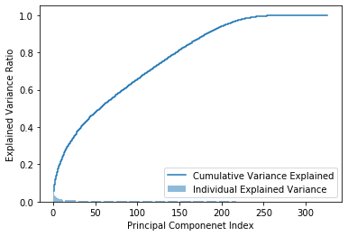

```python
plt.bar(range(1,327), var_exp, alpha = .5, align = 'center', label = 'Individual Explained Variance')

plt.step(range(1,327), cum_var_exp, where = 'mid', label = 'Cumulative Variance Explained')

plt.ylabel('Explained Variance Ratio')
plt.xlabel('Principal Componenet Index')
plt.legend(loc='best')
plt.show()
```

**Significant Findings**

We will pair the eigenvectors with their corresponding eigenvalues and project them onto a 2-dimensional subspace and observe the results.

```python
# making a listof (eigenvalues, eigenvector) tuples
eigen_pairs = [(np.abs(eigen_vals[i]), eigen_vecs[:,i]) for i in range(len(eigen_vals))]

#sort the (eigenvalue, eigenvector) tuples from high to low
"""eigen_pairs[0] is equivalent to the single eigenvalue for PC1 and the eigenvector that represents the 190 features of the data"""
eigen_pairs.sort(key=lambda k: k[0], reverse = True)

#collecting the two eigenvectors that correspond to the two largest eigenvalues

W = np.hstack((eigen_pairs[0][1][:,np.newaxis],
               eigen_pairs[1][1][:,np.newaxis]))

# printing the first 5 pairs
print('Matrix W: \n', W[:5])
```

```
Matrix W:
 [[-0.03112655 -0.00332737]
 [ 0.01428164  0.02652703]
 [-0.00576126  0.00453904]
 [ 0.0153833   0.02209266]
 [ 0.00340376  0.00048951]]
```

We can use this matrix to transform the training set into new features and plot them. First, we will observe the first 2 Principal Components with a logistic regression-based decision boundary to view the discriminatory ability of a logistic model using the Principal Components.

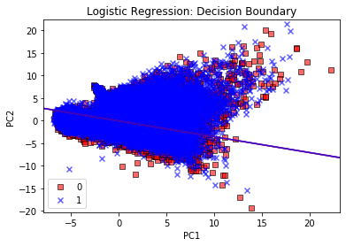

```python
#transforming data
X_pca = X_std.dot(W)

# identifying labels
y_pca = data_final.TARGET.copy()

#initializing the PCA transformer and logistic regression estimator:
pca = PCA(n_components =2)
lr = LogisticRegression(multi_class = 'ovr',
                        random_state = 1,
                        solver = 'lbfgs')
# dimensionality reduction:
X_pca = pca.fit_transform(X_std)
#fitting the logitistic regression model on the reduced dataset:
lr.fit(X_pca, y_pca)
plot_decision_regions(X_pca, y_pca, classifier = lr)
plt.title('Logistic Regression: Decision Boundary')
plt.xlabel('PC1')
plt.ylabel('PC2')
plt.legend(loc = 'lower left')
plt.show()
```

**Significant Findings**

From this plot, we can see that class separation is very poor and non-linear. We have two centroids where each has only a slight concentric-ellipse type of separation between the two classes. The decision boundary drawn by a logistic model is clearly unable to use the first two principal components to discriminate between defaults and non-defaulted loans.

We can also attempt to view the value of the third principal component to see if there is good separation when we add a third dimension.

```python
# getting three principal components
W3 = np.hstack((W,eigen_pairs[2][1][:,np.newaxis]))
W3.shape
```

```
(326, 3)
```

```python
#transforming training data
X_pca3 = X_std.dot(W3)
X_pca3.shape
```

```
(33778, 3)
```

```python
X_pca3[:10,:]
```

```
array([[-5.02937674, -0.98626814, -1.30637781],
       [-2.01549137, -6.42485912, 10.76923357],
       [ 2.28124558, -3.86540618, -1.64788073],
       [ 0.73152602,  0.1714851 ,  1.98469044],
       [-0.96959981,  1.64431276,  0.31434482],
       [-6.39735164, -0.50218682, -2.14297191],
       [ 6.84454901,  3.46870767,  4.46499208],
       [-2.17301617,  0.66477394,  0.55293713],
       [-5.07053559, -0.2440994 , -1.20476297],
       [-5.10194594, -1.73257925, -0.3966984 ]])
```

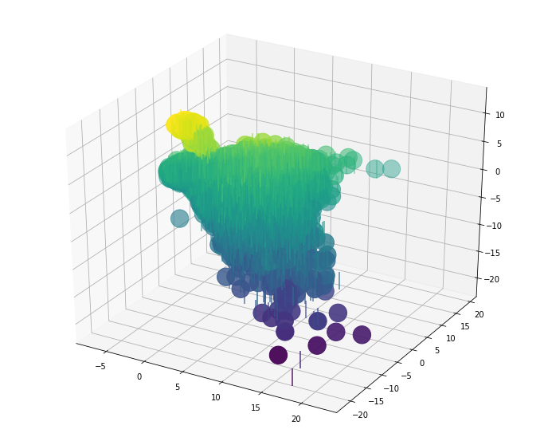

```python
fig = plt.figure(figsize=(12,10))
ax = fig.add_subplot(111, projection = '3d')


colors = ['r','g']
markers = ['o', '|']

# for each index and class in:
for idx, cl in enumerate(np.unique(y_pca)):
    ax.scatter3D(X_pca3[y_pca == cl, 0],
                X_pca3[y_pca == cl, 1],
                X_pca3[y_pca == cl, 2],
                label = cl,
                s=500,
                c = X_pca3[y_pca == cl, 2],
                cmap = 'viridis',
                marker = markers[idx])
```

**Significant Findings**

1. The overlap between the classes is so signficant even in the third dimension, that the boundary line is not clear.

### 1.1.2 Feature Importance Assessment

An analysis of feature importance was performed by removing features with high variance inflation factor (VIF) and ranking features by absolute mean feature importance from an ensemble of models (regularized logistic regression).

#### 1.1.2.1 Feature Removal By VIF

High VIF is an [indication of multicollinearity](https://www.statsmodels.org/stable/generated/statsmodels.stats.outliers_influence.variance_inflation_factor.html). Typically, limiting VIF of individual features to 5 is considered reasonable. For removal by VIF, features with high VIF were removed iteratively until the VIF for all remain features was less than 5. The VIF reduction method removed 75 features, leaving 251 features. The full list of dropped features is shown below.

```
transformer = ReduceVIF()
X = transformer.fit_transform(X_train)
```

```python
IFrame("./vif_features.html", width=700, height=400)
```

[interactive chart not shown]

#### 1.1.2.2 Feature Importance From Ensemble

The training data was split into training and validation sets (80/20) split - the validation split is used in the performance estimation. Feature Importance was estimated by training a logstic model with L2 regularization and a logistic model with L1 regularization on the training set with the reduced number of features. Once the models were fit, the model weights were extracted and combined for each feature. The features were ranked by the average of the absolute value of the model weights. The table is shown below

**Column Meanings**

- `Mean_Abs_Weight`: The mean of the absolute values of the weights assigned to features by the logistic models.
- `Feature`: The feature name.
- `l1_Weight`: The parameter weight assigned my the logistic model with L1 regularization.
- `l2_Weight`: The parameter weight assigned my the logistic model with L2 regularization.
- `Importance_Difference`: The difference btween the weight assigned by the LASSO logistic model and the weight assigned by the ridge logistic regression model.
- `Importance_Difference_%`: The percent difference between the weight assigned by the LASSO logistic model and the weight assigned by the ridge logistic regression model.

```python
IFrame("./feature_importance.html", width=1200, height=400)
```

[interactive chart not shown]

```python
X = X_train
X_val = X_test
y = y_train
y_val = y_test

# train logistic models
logistic_l1 = LogisticRegression(C = 0.01,
                                 penalty = 'l1',
                                 solver = 'saga',
                                 random_state = random_state)
logistic_l1.fit(X, y)

logistic_l2 = LogisticRegression(C = 0.01,
                                 penalty = 'l2',
                                 solver = 'lbfgs',
                                 random_state = random_state)
logistic_l2.fit(X, y)

# extract the l1 coefficients
coefs = logistic_l1.coef_
pd.set_option('display.max_rows', 500)
coefs_df = pd.DataFrame(data=coefs.flatten())
feats_df = X.columns
feats_df = feats_df.tolist()
feats_df = pd.DataFrame(feats_df)
df_new_coeffs = pd.concat([feats_df, coefs_df], axis=1).dropna()
df_new_coeffs.columns = ['Feature', 'Logistic Weight']
final_df_logistic_l1 = df_new_coeffs.sort_values('Logistic Weight')
final_df_logistic_l1['Abs Weight'] = np.abs(final_df_logistic_l1['Logistic Weight'])
final_df_logistic_l1.sort_values('Abs Weight', ascending=False, inplace = True)

# extract the l2 coefficients
coefs = logistic_l2.coef_
pd.set_option('display.max_rows', 500)
coefs_df = pd.DataFrame(data=coefs.flatten())
feats_df = X.columns
feats_df = feats_df.tolist()
feats_df = pd.DataFrame(feats_df)
df_new_coeffs = pd.concat([feats_df, coefs_df], axis=1).dropna()
df_new_coeffs.columns = ['Feature', 'Logistic Weight']
final_df_logistic_l2 = df_new_coeffs.sort_values('Logistic Weight')
final_df_logistic_l2['Abs Weight'] = np.abs(final_df_logistic_l2['Logistic Weight'])
final_df_logistic_l2.sort_values('Abs Weight', ascending=False, inplace = True)

# prevent risk of object corruption
l2 = final_df_logistic_l2.sort_values('Feature').copy().add_suffix('_l2')
l1 = final_df_logistic_l1.sort_values('Feature').copy().add_suffix('_l1')

# combine the feature weights, calculate mean abs, and sort
# just print the head
combined = pd.concat([l1, l2], keys=['Feature_l1', 'Feature_l2'], axis = 1)
combined['Average Weight'] = (combined['Feature_l1']['Abs Weight_l1']
                              + combined['Feature_l2']['Abs Weight_l2']) / 2
average_weights = pd.DataFrame()
average_weights['Mean_Abs_Weight'] = combined['Average Weight']
average_weights['Feature'] = combined['Feature_l1']['Feature_l1']
average_weights['l1_Weight'] = combined['Feature_l1']['Logistic Weight_l1']
average_weights['l2_Weight'] = combined['Feature_l2']['Logistic Weight_l2']
average_weights['Importance_Difference'] = average_weights['l1_Weight'] - average_weights['l2_Weight']
average_weights['Importance_Difference_%'] = (average_weights['Importance_Difference']
                                              / average_weights['Mean_Abs_Weight']
                                              * 100)
average_weights = average_weights.sort_values('Mean_Abs_Weight', ascending = False).reset_index(drop = True)
average_weights.head(10)
```

|  | Mean_Abs_Weight | Feature | l1_Weight | l2_Weight | Importance_Difference | Importance_Difference_% |
| --- | --- | --- | --- | --- | --- | --- |
| 0 | 0.399264 | EXT_SOURCE_2 | -0.402829 | -0.395699 | -0.007130 | -1.785808 |
| 1 | 0.381053 | EXT_SOURCE_3 | -0.377268 | -0.384837 | 0.007569 | 1.986399 |
| 2 | 0.257468 | NAME_EDUCATION_TYPE | -0.060687 | -0.454249 | 0.393562 | 152.858748 |
| 3 | 0.250792 | POS_CNT_INSTALMENT_FUTURE | 0.140188 | 0.361395 | -0.221208 | -88.203829 |
| 4 | 0.168159 | INSTA_AMT_PAYMENT | -0.037588 | -0.298730 | 0.261142 | 155.294656 |
| 5 | 0.161911 | CODE_GENDER | -0.155459 | -0.168363 | 0.012904 | 7.970049 |
| 6 | 0.158340 | PREV_CNT_PAYMENT | 0.150242 | 0.166439 | -0.016197 | -10.229270 |
| 7 | 0.147774 | EXT_SOURCE_1 | -0.149103 | -0.146446 | -0.002657 | -1.798160 |
| 8 | 0.134381 | FLAG_DOCUMENT_3 | 0.103911 | 0.164852 | -0.060941 | -45.349103 |
| 9 | 0.124358 | FLAG_OWN_CAR | 0.000000 | -0.248717 | 0.248717 | 200.000000 |

#### 1.1.2.3 Estimation of Performance Over Feature Space

Once the features were ranked, the number of features needed for classification was estimated by iterative training and testing a logistic model and a hist gradient boosting model on the ranked feature set. On each iteration, 5 features were added to the feature space used by the model for training and testing until the maximum feature space was reached. The following plots show the model performance over the feature space. The logistic model appears to stabilize once the top 50 features were added to the model, while the HGBM appears to stablity once the top 75 features were added to the model. The models were tested on the 20% validation split from the training data.

```python
# hold feature performance
log_acc = list()
log_recall = list()
log_pre = list()
feat_count = list()
hgbm_acc = list()
hgbm_recall = list()
hgbm_pre = list()
feat_count = list()

# init models
# models use baseline regularization
l = LogisticRegression(C = 0.01,
                       penalty = 'l2',
                       solver = 'lbfgs',
                       random_state = random_state)

clf = HistGradientBoostingClassifier(l2_regularization= 0,
                                     learning_rate= 0.1,
                                     loss= 'binary_crossentropy',
                                     max_iter= 100,
                                     max_leaf_nodes= 41,
                                     min_samples_leaf= 20,
                                     random_state = random_state)

# calculate performance over by iterative adding features
# with a step size of 5
for f_count in range(10, 260, 5):
    feat_count.append(f_count)

    l.fit(X[average_weights.iloc[0:f_count].Feature], y)

    # using it on test set
    y_pred = l.predict(X_val[average_weights.iloc[0:f_count].Feature])
    #results = confusion_matrix(y_test, y_pred)

    log_acc.append(accuracy_score(y_val, y_pred))
    log_pre.append(precision_score(y_val, y_pred))
    log_recall.append(recall_score(y_val, y_pred))

feat_count = list()
for f_count in range(10,260,5):
    feat_count.append(f_count)

    clf.fit(X[average_weights.iloc[0:f_count].Feature], y)

    # using it on test set
    y_pred = clf.predict(X_val[average_weights.iloc[0:f_count].Feature])
    #results = confusion_matrix(y_test, y_pred)

    hgbm_acc.append(accuracy_score(y_val, y_pred))
    hgbm_pre.append(precision_score(y_val, y_pred))
    hgbm_recall.append(recall_score(y_val, y_pred))
```

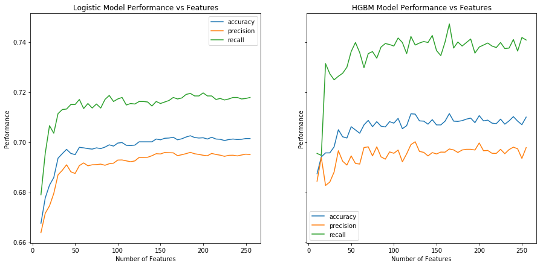

```python
# plot the performance of both models
fig, ax = plt.subplots(ncols=2, sharey = True, figsize=(15,7))

ax[0].plot(feat_count, log_acc, label = 'accuracy')
ax[0].plot(feat_count, log_pre, label = 'precision')
ax[0].plot(feat_count, log_recall, label = 'recall')
ax[0].legend()
ax[0].set_title('Logistic Model Performance vs Features')
ax[0].set_xlabel('Number of Features')
ax[0].set_ylabel('Performance')
#plt.ylim((0.68, 0.74))

ax[1].plot(feat_count, hgbm_acc, label = 'accuracy')
ax[1].plot(feat_count, hgbm_pre, label = 'precision')
ax[1].plot(feat_count, hgbm_recall, label = 'recall')
ax[1].legend()
ax[1].set_title('HGBM Model Performance vs Features')
ax[1].set_xlabel('Number of Features')
ax[1].set_ylabel('Performance')
#plt.ylim((0.68, 0.78))
plt.show();
```

```python
keepers = average_weights.Feature[:100].values
# using the previously scaled dataset and removing less important features
X_train = X_train[keepers]
X_test = X_test[keepers]
```

```python
X_train.shape
```

```
(39720, 100)
```

```python
profile = ProfileReport(X_train, minimal=True)
profile.to_file(output_file = 'Lab_2_data.html')
```

## 1.2 Describe the final dataset that is used for classification/regression (Q1B)

The final training set contains 39,720 records and the 100 most important attributes to predictor the value of `TARGET`. The features are a combination of continuous variables, binary indicators, and label encoded ordinal features. A full report of the distributions of the selected features is available in the following HTML rendered report:

```python
IFrame("./Lab_2_data.html", width=1200, height=400)
```

[interactive chart not shown]

Descriptions of the features selected as the 100 most important are given below.

```python
IFrame('./feature_descriptions.html', width=1200, height=400)
```

[interactive chart not shown]

# 2. Stage Four - Modeling and Evaluation (Q2)

## 2.1 Choose and explain your evaluation metrics (Q2A)

Due to the significant overlap between the classes in our dataset, we have elected to evaluate our models using the recall metric. Recall is the ratio of accurately predicted defaults to total defaults, which allows us to extract value from the model.

## 2.2 Choose the method you will use for dividing your data (Q2B)

We are using an 80/20 training : test set split.

As previously mentioned in section 1.2 (Data Description) we concluded that it was necessary to implement a sampling strategy on the training set in order to make a useful model for predicting loan defaults.

## 2.3 Three Classification Models (Q2C)

### 2.3.1 Histogram Based Gradient Boosted Decision Tree

#### Applying a Grid Search

```python
g_clf = HistGradientBoostingClassifier(random_state = random_state)

grid_values = {
    'loss': ['binary_crossentropy', 'categorical_crossentropy'],
    'learning_rate': [.05, .1],
    'max_iter': [100, 125],
    'max_leaf_nodes': [41, 51],
    'min_samples_leaf': [10, 20],
    'l2_regularization':[0,.01],
    'random_state': [random_state]
}

grid_clf = GridSearchCV(g_clf, param_grid = grid_values)

grid_clf.fit(X_train, y_train)
```

```
GridSearchCV(cv=None, error_score=nan,
             estimator=HistGradientBoostingClassifier(l2_regularization=0.0,
                                                      learning_rate=0.1,
                                                      loss='auto', max_bins=255,
                                                      max_depth=None,
                                                      max_iter=100,
                                                      max_leaf_nodes=31,
                                                      min_samples_leaf=20,
                                                      n_iter_no_change=None,
                                                      random_state=1,
                                                      scoring=None, tol=1e-07,
                                                      validation_fraction=0.1,
                                                      verbose=0,
                                                      warm_start=False),
             iid='deprecated', n_jobs=None,
             param_grid={'l2_regularization': [0, 0.01],
                         'learning_rate': [0.05, 0.1],
                         'loss': ['binary_crossentropy',
                                  'categorical_crossentropy'],
                         'max_iter': [100, 125], 'max_leaf_nodes': [41, 51],
                         'min_samples_leaf': [10, 20], 'random_state': [1]},
             pre_dispatch='2*n_jobs', refit=True, return_train_score=False,
             scoring=None, verbose=0)
```

```python
print(grid_clf.best_params_)
```

```
{'l2_regularization': 0.01, 'learning_rate': 0.1, 'loss': 'binary_crossentropy', 'max_iter': 100, 'max_leaf_nodes': 51, 'min_samples_leaf': 10, 'random_state': 1}
```

```python
clf = HistGradientBoostingClassifier(l2_regularization= 0,
                                     learning_rate= 0.1,
                                     loss= 'binary_crossentropy',
                                     max_iter= 100,
                                     max_leaf_nodes= 41,
                                     min_samples_leaf= 20,
                                     random_state = random_state)
hgbm_fit_time_start = time()
clf.fit(X_train,y_train)
hgbm_fit_time_end = time()
print('5-fold cross validation results: ',cross_val_score(clf, X_train, y_train, cv = 5, scoring = 'recall'))
```

```
5-fold cross validation results:  [0.71299094 0.70417925 0.68907351 0.69964753 0.69209466]
```

```python
hgbm_predict_time_start = time()
hgbm_preds = clf.predict(X_test)
hgbm_predict_time_end = time()
results = confusion_matrix(y_test, hgbm_preds)

accuracy = (results[0][0] + results[1][1])/(len(hgbm_preds))
precision = results[1][1]/(results[0][1] + results[1][1])
recall = results[1][1]/ (results[1][0] + results[1][1])

print(results,
      '\nAccuracy: ' + str(accuracy),
      '\nPrecision: ' + str(precision),
      '\nRecall: ' + str(recall))
```

```
[[3392 1573]
 [1284 3681]]
Accuracy: 0.7122860020140986
Precision: 0.7006090597639894
Recall: 0.7413897280966767
```

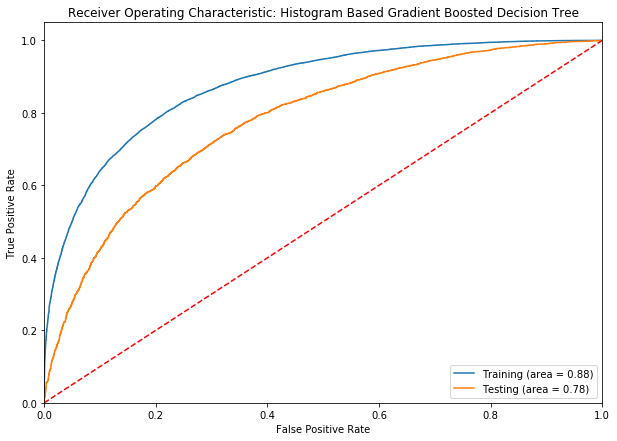

```python
fpr = dict() # false positive rate
tpr = dict() # true positive rate
roc_auc = dict() # area under the curve



fpr, tpr, thresholds = roc_curve(y_train, grid_clf.predict_proba(X_train)[:,1])
roc_auc = auc(fpr,tpr)

fpr_t, tpr_t, thresholds_t = roc_curve(y_test, grid_clf.predict_proba(X_test)[:,1])
roc_auc2 = auc(fpr_t,tpr_t)

#plotting
plt.figure(figsize = (10, 7))
plt.plot(fpr, tpr, label= 'Training (area = %0.2f)' % roc_auc)
plt.plot(fpr_t, tpr_t, label= 'Testing (area = %0.2f)' % roc_auc2)
plt.plot([0,1],[0,1], 'r--')
plt.xlim([0.0, 1.0])
plt.ylim([0.0,1.05])
plt.xlabel('False Positive Rate')
plt.ylabel('True Positive Rate')
plt.title('Receiver Operating Characteristic: Histogram Based Gradient Boosted Decision Tree')
plt.legend(loc = 'lower right')
plt.show()
```

### 2.3.1.2 Random Forest

```python
model = RandomForestClassifier(random_state = random_state,
                               min_samples_leaf = 3,
                               min_samples_split = 75,
                               max_depth = 30)
rf_fit_time_start = time()
model.fit(X_train, y_train)
rf_fit_time_end = time()

rf_predict_time_start = time()
y_pred = model.predict(X_test)
rf_predict_time_end = time()

classification_report(y_test, y_pred)
```

```
Classification Report

Confusion Matrix
Predicted   0.0   1.0   All
True
0.0        3336  1629  4965
1.0        1353  3612  4965
All        4689  5241  9930

Accuracy: 69.97%
Precision: 68.92%
Recall: 72.75%
```

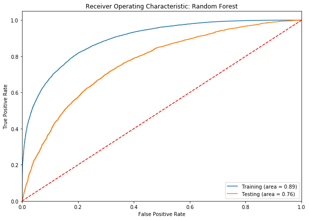

```python
fpr = dict() # false positive rate
tpr = dict() # true positive rate
roc_auc = dict() # area under the curve

fpr2 = dict() # false positive rate
tpr2 = dict() # true positive rate
roc_auc2 = dict() # area under the curve

fpr, tpr, thresholds = roc_curve(y_train,
                                 model.predict_proba(X_train)[:,1])
roc_auc = auc(fpr,tpr)

fpr2, tpr2, thresholds = roc_curve(y_test,
                                   model.predict_proba(X_test)[:,1])
roc_auc2 = auc(fpr2,tpr2)

#plotting
plt.figure(figsize = (10, 7))
plt.plot(fpr, tpr, label= 'Training (area = %0.2f)' % roc_auc)
plt.plot(fpr2, tpr2, label= 'Testing (area = %0.2f)' % roc_auc2)
plt.plot([0,1],[0,1], 'r--')
plt.xlim([0.0, 1.0])
plt.ylim([0.0,1.05])
plt.xlabel('False Positive Rate')
plt.ylabel('True Positive Rate')
plt.title('Receiver Operating Characteristic: Random Forest')
plt.legend(loc = 'lower right')
plt.show()
```

#### Tuning Random Forest

The random forest was tuned over `max_depth`, `min_samples_leaf`, and `min_samples_split` in a grid search with cross validation. As shown in the plot of the performance over parameter values, there is little difference over the hyperparameter space. The best parameters chosen by grid search are `max_depth: 30`, `min_samples_leaf: 3`, and `min_samples_split: 75`. These values were used in the final random forest classifier.

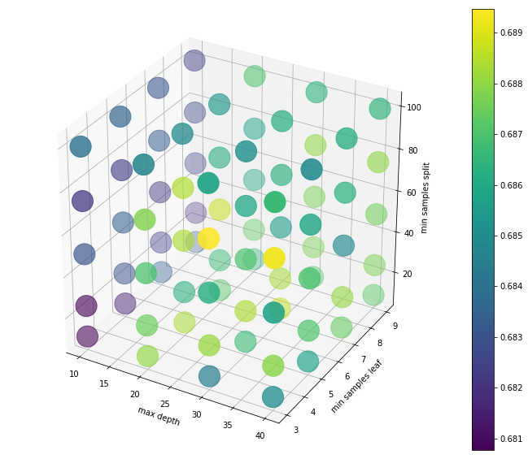

```python
# read in previous saved grid search results
RFclassifier_Grid_Search = pd.read_csv('RFclassifier_Grid_Search.csv')

fig = plt.figure(figsize=(12,10))
ax = fig.add_subplot(111, projection = '3d')


colors = ['r','g']
markers = ['o', '|']

# for each index and class in:
scatter = ax.scatter3D(RFclassifier_Grid_Search.max_depth,
            RFclassifier_Grid_Search.min_samples_leaf,
            RFclassifier_Grid_Search.min_samples_split,
            s = (RFclassifier_Grid_Search.scores*1000),
            c = (RFclassifier_Grid_Search.scores*1),
            cmap = 'viridis')
ax.set_xlabel('max depth')
ax.set_ylabel('min samples leaf')
ax.set_zlabel('min samples split')
fig.colorbar(scatter);
```

### 2.3.1.2 Logistic Regression

Logistic regression is a classification model that performs well using linearly separable classes. In this case, our response classes – which refer to loan default status – are binary with a loan default represented with the integer 1 and non-default represented as integer 0. The logistic regression model utilizes an odds ratio, which represents the probability of an event occurring rather than an event not occurring. In the case of this classification model, the event – also called a “positive event” – is a representation of a loan being defaulted. The produced odds ratio is then transformed logarithmically into a probability ranging from 0 to 1. Because there is a binary split in the classification of our output, the threshold for determining if a positive event has occurred or not is 0.5.

```python
logistic = LogisticRegression(solver='liblinear', random_state=1, C = 0.03359818286283781)
l_fit_time_start = time()
logistic.fit(X_train, y_train);
l_fit_time_end = time()
```

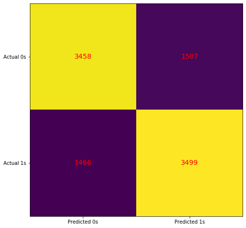

```python
confused_matrix = confusion_matrix(y_test, logistic.predict(X_test))

fig, ax = plt.subplots(figsize=(8, 8))
ax.imshow(confused_matrix)
ax.grid(False)
ax.xaxis.set(ticks=(0, 1), ticklabels=('Predicted 0s', 'Predicted 1s'))
ax.yaxis.set(ticks=(0, 1), ticklabels=('Actual 0s', 'Actual 1s'))
ax.set_ylim(1.5, -0.5)
for i in range(2):
    for j in range(2):
        ax.text(j, i, confused_matrix[i, j], ha='center', va='center', color='red', fontsize='14')
plt.show()
```

```python
l_predict_time_start = time()
y_pred_log = logistic.predict(X_test)
l_predict_time_end = time()
classification_report(y_test, y_pred_log)
```

```
Classification Report

Confusion Matrix
Predicted   0.0   1.0   All
True
0.0        3458  1507  4965
1.0        1466  3499  4965
All        4924  5006  9930

Accuracy: 70.06%
Precision: 69.90%
Recall: 70.47%
None
```

**ROC Curve**

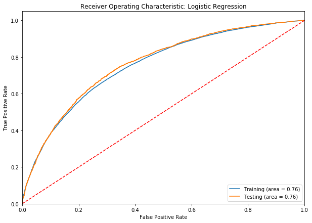

```python
fpr, tpr, thresholds = roc_curve(y_train, logistic.predict_proba(X_train)[:,1])
roc_auc = auc(fpr,tpr)

fpr_t, tpr_t, thresholds_t = roc_curve(y_test, logistic.predict_proba(X_test)[:,1])
roc_auc2 = auc(fpr_t,tpr_t)

#plotting
plt.figure(figsize = (10, 7))
plt.plot(fpr, tpr, label= 'Training (area = %0.2f)' % roc_auc)
plt.plot(fpr_t, tpr_t, label= 'Testing (area = %0.2f)' % roc_auc2)
plt.plot([0,1],[0,1], 'r--')
plt.xlim([0.0, 1.0])
plt.ylim([0.0,1.05])
plt.xlabel('False Positive Rate')
plt.ylabel('True Positive Rate')
plt.title('Receiver Operating Characteristic: Logistic Regression')
plt.legend(loc = 'lower right')
plt.show()
```

### Tuning Logstic Regression

Performing grid search with cross validation on the training data for tuning yielded better results. Because the results were improved, we used the regularization parameter C = 0.03. We chose this value over the top suggestion, 206.91, because the performance is relatively flat beyond the 0.03 threshold, we assessed a reasonable risk of under-regularizing.

The results of the model using hyperparameter C = 206.91 yielded 69.75% precision and 70.55% recall with accuracy recorded at 69.98%. The results of the model using hyperparameter C = 0.03 were within the same range, but agreed as slightly more reliable. At C = 0.03, precision measured at 69.90% while recall measured 70.47% with a 70.06% accuracy.

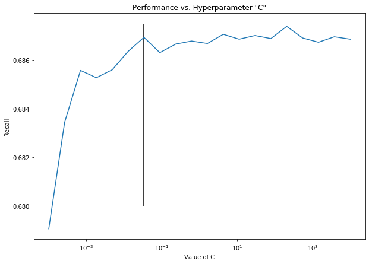

```python
c_vals = list()

scores = clf.cv_results_['mean_test_score']
for param_set in clf.cv_results_['params']:
    c_vals.append(param_set['C'])

plt.figure(figsize = (10, 7))
plt.plot(c_vals, scores)
plt.xscale("log")
plt.xlabel('Value of C')
plt.ylabel('Recall')
plt.title('Performance vs. Hyperparameter "C"')
plt.vlines(x=0.03359818286283781, ymin=0.68, ymax=0.6875);
```

## 2.3.2 Three Regression Models (Q2C)

To perform a regression on a continuous variable, we picked a variable with the highest importance to the initial application, EXT_SOURCE_2. Since our predictor and our modeling strategy has changed, we must re-evaluate our assumptions to match those of linear regression. We are aware of several highly skewed features, such as `AMT_INCOME_TOTAL` and `AMT_ANNUITY` and must apply a log transformation to meet the normality and equal variance assumptions of Linear Regression.

```python
data_reg = read_clean_data(preimpute = False)
```

```python
data_reg = data_reg.dropna(axis=1)
data_reg.shape
```

```
(307511, 70)
```

We also viewed the variables for evidence of multicollinearity and found that all `EXT_SOURCE` variables were not at all collinear. Although the `EXT_SOURCE` variables are highly skewed, the documentation states that they are already standardized, making further transformations of these variables problematic. We have decided not to transform these variables. Our dataset also contains a large number of binary indicator variables, so these features will not be transformed.

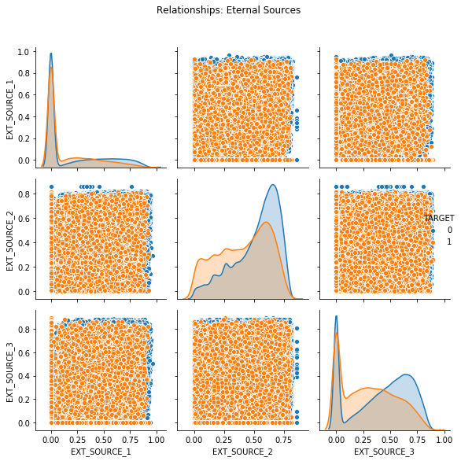

```python
cols = ['EXT_SOURCE_1', 'EXT_SOURCE_2', 'EXT_SOURCE_3','TARGET']
g = sns.pairplot(data_reg[cols], hue = 'TARGET')
g.fig.suptitle('Relationships: Eternal Sources', y= 1.08)
plt.tight_layout()
plt.show()
```

```python
# applying log transformations to non-binary values
log_data = data_reg.copy()
for col in log_data.columns.values:
    if log_data[col].min() != 0 and log_data[col].max() != 1:
        log_data[col] = log_data[col].apply(np.log)
```

```python
log_data.describe()
```

|  | SK_ID_CURR | TARGET | NAME_CONTRACT_TYPE | FLAG_OWN_CAR | FLAG_OWN_REALTY | AMT_INCOME_TOTAL | AMT_CREDIT | NAME_TYPE_SUITE | NAME_INCOME_TYPE | NAME_EDUCATION_TYPE | ... | AMT_REQ_CREDIT_BUREAU_DAY | AMT_REQ_CREDIT_BUREAU_WEEK | AMT_REQ_CREDIT_BUREAU_MON | AMT_REQ_CREDIT_BUREAU_QRT | AMT_REQ_CREDIT_BUREAU_YEAR | EMPLOYED | cnt_child | cnt_family | CREDIT_INCOME_RATIO | PERCENT_EMPLOYED_TO_AGE |
| --- | --- | --- | --- | --- | --- | --- | --- | --- | --- | --- | --- | --- | --- | --- | --- | --- | --- | --- | --- | --- | --- |
| count | 307511.000000 | 307511.000000 | 307511.000000 | 307511.000000 | 307511.000000 | 307511.000000 | 307511.000000 | 307511.000000 | 307511.000000 | 307511.000000 | ... | 307511.000000 | 307511.000000 | 307511.000000 | 307511.000000 | 307511.000000 | 307511.000000 | 307511.000000 | 307511.000000 | 307511.000000 | 307511.000000 |
| mean | 12.457158 | 0.080729 | 0.095213 | 0.340108 | 0.693673 | 11.909238 | 13.070105 | 5.227192 | 4.670288 | 3.188273 | ... | 0.006055 | 0.029723 | 0.231293 | 0.229631 | 1.643447 | 0.819928 | 1.401147 | 1.137120 | 1.160868 | 0.128615 |
| std | 0.414200 | 0.272419 | 0.293509 | 0.473746 | 0.460968 | 0.488910 | 0.715196 | 1.775645 | 2.544525 | 1.298753 | ... | 0.103037 | 0.190728 | 0.856810 | 0.744059 | 1.855821 | 0.384248 | 0.915792 | 0.863878 | 0.675518 | 0.135117 |
| min | 11.512945 | 0.000000 | 0.000000 | 0.000000 | 0.000000 | 10.152299 | 10.714418 | 0.000000 | 0.000000 | 0.000000 | ... | 0.000000 | 0.000000 | 0.000000 | 0.000000 | 0.000000 | 0.000000 | 0.000000 | 0.000000 | -5.337554 | 0.000000 |
| 25% | 12.150272 | 0.000000 | 0.000000 | 0.000000 | 0.000000 | 11.630709 | 12.506177 | 6.000000 | 3.000000 | 2.000000 | ... | 0.000000 | 0.000000 | 0.000000 | 0.000000 | 0.000000 | 1.000000 | 0.000000 | 1.000000 | 0.702437 | 0.021559 |
| 50% | 12.536103 | 0.000000 | 0.000000 | 0.000000 | 1.000000 | 11.899208 | 13.149066 | 6.000000 | 7.000000 | 4.000000 | ... | 0.000000 | 0.000000 | 0.000000 | 0.000000 | 1.000000 | 1.000000 | 2.000000 | 1.000000 | 1.183280 | 0.088645 |
| 75% | 12.813505 | 0.000000 | 0.000000 | 1.000000 | 1.000000 | 12.218495 | 13.603121 | 6.000000 | 7.000000 | 4.000000 | ... | 0.000000 | 0.000000 | 0.000000 | 0.000000 | 3.000000 | 1.000000 | 2.000000 | 2.000000 | 1.640913 | 0.191000 |
| max | 13.030807 | 1.000000 | 1.000000 | 1.000000 | 1.000000 | 18.577684 | 15.214227 | 7.000000 | 7.000000 | 4.000000 | ... | 9.000000 | 8.000000 | 27.000000 | 261.000000 | 25.000000 | 1.000000 | 2.000000 | 3.000000 | 4.439550 | 0.728811 |

8 rows × 70 columns

```python
X_train_r, X_test_r, y_train_r, y_test_r = train_test_split(log_data.drop(labels = ['EXT_SOURCE_2'], axis = 1), log_data.EXT_SOURCE_2, test_size = .2, random_state=random_state)
print('x train:', X_train_r.shape, '\ny train: ', y_train_r.shape, '\nx test: ', X_test_r.shape, '\ny test: ', y_test_r.shape)
```

```
x train: (246008, 69)
y train:  (246008,)
x test:  (61503, 69)
y test:  (61503,)
```

#### Grid searching for Linear Regression

```python
sklm = LinearRegression(normalize=True)
sklm.fit(X_train_r, y_train_r)

sklm_pred = sklm.predict(X_test_r)

scores = cross_val_score(sklm, X_test_r, y_test_r, cv=5)
```

```
MSE test:  EXT_SOURCE_2    0.03111
dtype: float64 CV scores:  [   0.15811436 -111.45060257    0.15633389    0.16738395    0.1514178 ]
Mean CV score:  -22.163470511971333
```

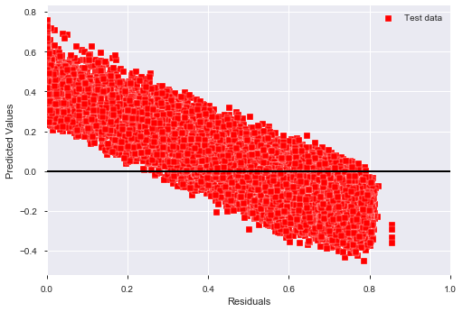

```python
def resids(real, predicted):

    plt.scatter(real, real - predicted,
                c = 'red', marker = 's', edgecolor = 'white',
                label = 'Test data')
#     plt.scatter(ys2_train, (y_pred_train - ys2_train),
#                 c = 'steelblue', marker = 'o', edgecolor = 'white',
#                label='Train data')
    plt.xlabel('Residuals')
    plt.ylabel('Predicted Values')
    plt.legend(loc='bottom right')
    plt.hlines(y = 0, xmin = 0, xmax = 1, color = 'black', lw = 2)
    plt.xlim([0, 1])
    plt.show()
print('MSE test: ', ((sklm_pred - y_test_r)**2).mean(),
      "CV scores: ", scores,
      "\nMean CV score: ", scores.mean())

resids(y_test_r, sklm_pred)
```

**Significant Findings**

As indicated in the residual plot above, there is a trend in the plotting of residuals against predicted values such that as the predicted value increases, the residuals decrease. However, the residuals increase beyond zero. Rather than forming a random spread centered roughly around zero, this trend indicates the bounding in the target variable. Further analysis and resolving issues with data sampling from the loan application process could provide a more desired random spread of actual vs. predicted values.

EXT_SOURCE_2 is standardized and bounded between the values 0 and 1. The method of standardization is not revealed; it is possible that it could be centered or transformed. However, the methodology is not revealed. Consequently, we were unable to accurately back-transform the data to determine its true distribution. Also, the bounding of the predictor variable is evident in the bounded residual pattern in the plots of residuals vs. predicted values. Despite the obvious bounding of the residuals, the residuals are randomly distributed within the boundaries of EXT_SOURCE_2.

With respect to the external cross validation statistics, the five folds in the cross validation provide the lowest mean score. However, this is not a reliable metric as the second fold's score is -111 compared to the other four that are roughly 0.15. The cause is likely due to variation in the data that is not well-managed by the linear model. To account for this issue, we used the median CV score to evaluate the fittedness of the model to the data.

### Bayesian Ridge Regression Modeling

```python
y_train_r = pd.DataFrame(y_train_r)
y_test_r = pd.DataFrame(y_test_r)

brr = BayesianRidge(alpha_1 = 1, alpha_2 = 0)
brr.fit(X_train_r, y_train_r);
```

```python
brr_pred = brr.predict(X_test_r)

from sklearn.model_selection import cross_val_score
scores = cross_val_score(brr, X_train_r, y_train_r, cv=5)
```

```python
def resids(real, predicted):

    plt.scatter(real, real - predicted,
                c = 'red', marker = 's', edgecolor = 'white',
                label = 'Test data')
    plt.xlabel('Predicted Values')
    plt.ylabel('Residuals')
    plt.legend(loc='bottom right')
    plt.hlines(y = 0, xmin = 0, xmax = 1, color = 'black', lw = 2)
    plt.xlim([0, 1])
    plt.show()
```

```python
brr_pred1 = pd.DataFrame(brr_pred)
brr_pred1 = brr_pred1.to_numpy()

print('MSE test: ', ((brr_pred1 - y_test_r)**2).mean(),
      "CV scores : ", scores,
     "\nMean CV score: ", scores.mean())
```

```
MSE test:  EXT_SOURCE_2    0.031111
dtype: float64 CV scores :  [0.15818291 0.15671795 0.16302134 0.15817785 0.15718438]
Mean CV score:  0.15865688749661414
```

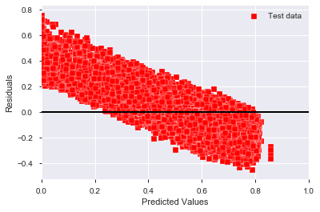

```python
brr_pred1 = pd.DataFrame(brr_pred)
brr_pred1 = brr_pred1.to_numpy()
scores = cross_val_score(brr, X_train_r, y_train_r, cv=5)

print('MSE test: ', ((brr_pred1 - y_test_r)**2).mean(),
      "CV scores : ", scores,
      "\nMean CV score: ", scores.mean())

resids(y_test_r, brr_pred1)
```

NOTE: With respect to the residual plot above, please refer to comments under the residual plot for linear regression.

```python
from sklearn import linear_model
lasso = linear_model.Lasso(alpha = 1)
lasso.fit(X_train_r, y_train_r)

lasso_pred = lasso.predict(X_test_r)
lasso_pred = pd.DataFrame(lasso_pred)
lasso_pred1 = lasso_pred.to_numpy()

scores = cross_val_score(lasso, X_train_r, y_train_r, cv=5)
```

[output not shown]

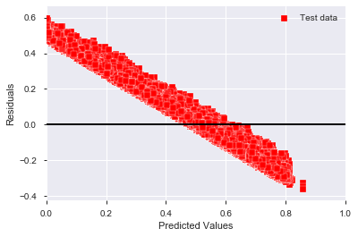

```python
print('MSE test: ', ((lasso_pred1 - y_test_r)**2).mean(),
      "CV scores : ", scores,
     "\nMean CV score: ", scores.mean())

resids(y_test_r, lasso_pred1)
```

NOTE: Please refer to linear regression for comments on the spread of actual compared to predicted values respective of regression modeling.

### Random Forest Regression Modeling

```python
RF_reg = RandomForestRegressor(random_state = random_state)

grid_values = {
    'n_estimators': [10, 20],
    'max_depth': [10, 20],
    'max_features':[.25, .15],
    'min_impurity_decrease':[.01, .05],
    'max_leaf_nodes': [41, 51],
    'min_samples_leaf': [10, 20],
    'ccp_alpha':[0,.01],
    'n_jobs':[6],
    'random_state': [random_state]
}

RF_reg_cv = GridSearchCV(RF_reg, param_grid = grid_values)

RF_reg_cv.fit(X_train_r, y_train_r)
```

```python
print(RF_reg_cv.best_params_)
```

```
{'ccp_alpha': 0, 'max_depth': 10, 'max_features': 0.25, 'max_leaf_nodes': 41, 'min_impurity_decrease': 0.01, 'min_samples_leaf': 10, 'n_estimators': 20, 'n_jobs': 6, 'random_state': 1}
```

```python
RF_reg_train = RF_reg_cv.predict(X_train_r)
RF_reg_pred = RF_reg_cv.predict(X_test_r)

#scores = cross_val_score(RF_reg_cv, X_train_r, y_train_r, cv=5)
print('MSE training: ', ((RF_reg_train - y_train_r)**2).mean())
print('MSE test: ', ((RF_reg_pred - y_test_r)**2).mean())
```

```
MSE training:  0.03698586021984146
MSE test:  0.037017559954723944
```

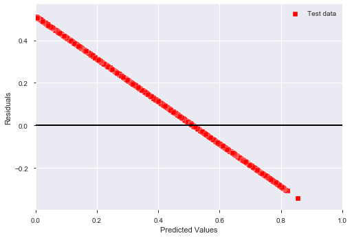

```python
resids(y_test_r, RF_reg_pred)
```

NOTE: Please refer to linear regression for comments on the spread of actual compared to predicted values respective of regression modeling. However, please note that the Random Forest regressor is predicting the mean.

## 2.4 Analyze the results using your chosen method of evaluation (Q2D)

### 2.4.1 Analyze the results using your chosen method of classification evaluation (Q2D)

#### Logistic Regression

Moreover, trainig times for the logistic model were the lowest; close to the gradient boosting classifier (but less time nonetheless) and much less than the random forest. Respective of prediction times, the logistic model required roughly one-tenth of the time the gradient boosting and random forest models required.

### 2.4.2 Analyze the results using your chosen method of regression evaluation (Q2D)

#### Bayesian Ridge Regression

As mentioned in the corresponding sections above, the Bayesian Ridge Regression model provided the most consistent cross-validation statistics across all folds. When considering these scores and the issues translated from the residuals plots, the Bayesian Ridge Regression model is the model selected for predicting EXT_SOURCE_2. The consistent cross validation scores are around 0.15 across all folds of the test. This indicates a more stable and reliable model than provided by pure linear regression. Additionally, Random Forest Regression did not generate useful predictions; it appears to have predicted the mean. Consequently, of the three models, Bayesian Ridge Regression is the model we selected for predicting EXT_SOURCE_2.

## 2.5 Discuss the advantages of each model for each classification task (Q2E)

The classification results show little difference in performance between the three models (summarized in the bar chart below). However, from the ROC curves of each model, it is apparent that the tree based models (RF and HGMB) are tending to overfit to the training data dispite using hyper parameters to limit the models. If the tree based models are overfitting to the training data, then the tree based models may not perform as well as expected on new instances of data. The ROC curves for the logistic model show that it performs similarly on the training and testing set. This is an advatange of the logistic model over the tree based models.

The last pair of bar charts show the training time and prediction time for each model. The logistic model takes the least time in both cases. If this model was deployed in an environment where online retraining was necessary, the low training times of the logistic model and the HGBM model would would be a significant advantage over the random forest model. For prediction times, the logistic model is signifiantly faster. If this system was deployed in an environment where a large number of predictions were necessary, this model would provide a significant advantage over the tree based models.

Since the model recalls are similar, the logistic regression model does not show an indication of overfitting, and the execution times of the logistic model are smaller than the other two models, we will choose this the logistic regression model for the classification task.

[figure not shown]

## 2.6 Which attributes from your analysis are most important (Q2F)

The most important features of were revealed through a comparison of L1 and L2 regularization. The mean absolute weight of the L1 and L2 weightings was the determining factor in the selection of features for the final model.

Noteable findings:

```python
average_weights.head(10)
```

|  | Mean_Abs_Weight | Feature | l1_Weight | l2_Weight | Importance_Difference | Importance_Difference_% |
| --- | --- | --- | --- | --- | --- | --- |
| 0 | 0.399264 | EXT_SOURCE_2 | -0.402829 | -0.395699 | -0.007130 | -1.785808 |
| 1 | 0.381053 | EXT_SOURCE_3 | -0.377268 | -0.384837 | 0.007569 | 1.986399 |
| 2 | 0.257468 | NAME_EDUCATION_TYPE | -0.060687 | -0.454249 | 0.393562 | 152.858748 |
| 3 | 0.250792 | POS_CNT_INSTALMENT_FUTURE | 0.140188 | 0.361395 | -0.221208 | -88.203829 |
| 4 | 0.168159 | INSTA_AMT_PAYMENT | -0.037588 | -0.298730 | 0.261142 | 155.294656 |
| 5 | 0.161911 | CODE_GENDER | -0.155459 | -0.168363 | 0.012904 | 7.970049 |
| 6 | 0.158340 | PREV_CNT_PAYMENT | 0.150242 | 0.166439 | -0.016197 | -10.229270 |
| 7 | 0.147774 | EXT_SOURCE_1 | -0.149103 | -0.146446 | -0.002657 | -1.798160 |
| 8 | 0.134381 | FLAG_DOCUMENT_3 | 0.103911 | 0.164852 | -0.060941 | -45.349103 |
| 9 | 0.124358 | FLAG_OWN_CAR | 0.000000 | -0.248717 | 0.248717 | 200.000000 |

# 3. Stage Five - Deployment (Q3)

## 3.1 Next Stage Deployment

The next stage in the CRISP-DM is deployment. After model building and evaluation, we are ready to deploy our code representation of the model into a production environment and solve our original business problem. Our business problem is to give Home Credit loan evaluators access to a model that evaluates an applicant’s current and past financial history in determining whether to approve the requested loan.

#### How useful is your model for interested parties?

We believe this model would be useful for loan departments loan evaluators. This is contingent of discovering how some of the external variables are created. With this and some additional consistancy in top scoring features we could improve the accuracy

#### How would you measure the model's value if it was used by these parties?

This model should be tested in parrellel to present evaluation proceess. Then after a set period of time compare human evaluation to model based accuracy. If the results were the same, the minimum resulting savings would be the salaries of the loan evaluators. Added value would result from the acceleration of the loan approval process.

#### How would your deploy your model for interested parties?

Depending on the resources, available, models can be deployed as batch or real-time predictions. Home Credits current process is a batch implementation. The applicant fills out the form which is then digitized and sent to the loan approval department. During the loan approval, the collected data will need to be cleaned and normalized before processed through the machine learning predictive model.

#### How often would the model need to be updated?

The metrics for the customer is continually updated. On a scheduled cycle, this new dataset is analyzed through the current model. Doing batch cycles will allow for consistency in whether an applicant is approved or not. However, model designs will change as newer technology are available or changing business environments make reengineering required.

#### What other data should be collected?

In addition to the clarification of data we have described above, there would be a tremendous value in the financials for the industry that the individual is working. These financials could assist in prediction of any future concerns for the applicants present income.

Below is a typical example of a batch deployment [1].

[figure not shown]

## References

[1] J. Kervizic, Overview of Different Approaches to Deploying Machine Learning Models in Production, June 2016. Accessed on: Feb. 15, 2019. [Online]. Available: https://www.kdnuggets.com/2019/06/approaches-deploying-machine-learning-production.html

# A1. Parameter Tuning

The code and output of model tuneing in shown below.

## Random Forest Classification

```
scores = ['precision', 'recall']

# tuning parameters
tuned_parameters = [{'min_samples_leaf':[3, 5, 7, 9],
                    'min_samples_split': [10, 25, 50, 75, 100],
                    'max_depth': [10, 20, 30, 40]}]

for score in scores:
    print("# Tuning hyper-parameters for %s" % score)
    print()

    clf = GridSearchCV(
        RandomForestClassifier(random_state = 42),
        tuned_parameters,
        scoring='%s_macro' % score
    )
    clf.fit(X_train[average_weights.iloc[0:100].Feature],
            y_train)

    print("Best parameters set found on development set:")
    print()
    print(clf.best_params_)
    print()
    print("Grid scores on development set:")
    print()
    means = clf.cv_results_['mean_test_score']
    stds = clf.cv_results_['std_test_score']
    for mean, std, params in zip(means, stds, clf.cv_results_['params']):
        print("%0.3f (+/-%0.03f) for %r"
              % (mean, std * 2, params))
    print()

    print("Detailed classification report:")
    print()
    print("The model is trained on the full development set.")
    print("The scores are computed on the full evaluation set.")
    print()
    y_true, y_pred = y_test, clf.predict(X_test[average_weights.iloc[0:100].Feature])
    classification_report(y_true, y_pred)
    print()
    # save off the cv objects
    if score == 'precision':
        pre_cv = clf
    else:
        recall_cv = clf

# get scores from cv object
scores = recall_cv.cv_results_['mean_test_score']

max_depth = list()
min_samples_leaf = list()
min_samples_split = list()

for param_set in recall_cv.cv_results_['params']:
    max_depth.append(param_set['max_depth'])
    min_samples_leaf.append(param_set['min_samples_leaf'])
    min_samples_split.append(param_set['min_samples_split'])

#store res in dataframe for look up later
RFclassifier_Grid_Search = pd.DataFrame(
    list(
        zip(
            scores,
            max_depth,
            min_samples_leaf,
            min_samples_split
        )
    ), columns = [
        'scores',
        'max_depth',
        'min_samples_leaf',
        'min_samples_split'
    ]
)

# Save off results
RFclassifier_Grid_Search.to_csv('RFclassifier_Grid_Search.csv', index = False)
```

```python
IFrame("./rf_tuning.html", width=800, height=400)
```

[interactive chart not shown]

## Logistic Regression

```
# scoring metrics
from sklearn.model_selection import GridSearchCV
scores = ['precision', 'recall']

# Create tuned parameters.
tuned_parameters = [{'C':np.logspace(-4, 4, 20)}]

for score in scores:
    print("# Tuning hyper-parameters for %s" % score)
    print()

    clf = GridSearchCV(
        LogisticRegression(random_state = random_state),
        tuned_parameters,
        scoring='%s_macro' % score
    )
    clf.fit(X_train, y_train)

    print("Best parameters set found on development set:")
    print()
    print(clf.best_params_)
    print()
    print("Grid scores on development set:")
    print()
    means = clf.cv_results_['mean_test_score']
    stds = clf.cv_results_['std_test_score']
    for mean, std, params in zip(means, stds, clf.cv_results_['params']):
        print("%0.3f (+/-%0.03f) for %r"
              % (mean, std * 2, params))
    print()

    print("Detailed classification report:")
    print()
    print("The model is trained on the full development set.")
    print("The scores are computed on the full evaluation set.")
    print()
    y_true, y_pred = y_test, clf.predict(X_test)
    print(classification_report(y_true, y_pred))
    print()

# Fit on data
best_clf = clf.fit(X_train, y_train)
```

```
# Tuning hyper-parameters for precision

Best parameters set found on development set:

{'C': 206.913808111479}

Grid scores on development set:

0.679 (+/-0.011) for {'C': 0.0001}
0.683 (+/-0.009) for {'C': 0.00026366508987303583}
0.686 (+/-0.009) for {'C': 0.0006951927961775605}
0.685 (+/-0.008) for {'C': 0.0018329807108324356}
0.686 (+/-0.009) for {'C': 0.004832930238571752}
0.686 (+/-0.008) for {'C': 0.012742749857031334}
0.687 (+/-0.010) for {'C': 0.03359818286283781}
0.686 (+/-0.010) for {'C': 0.08858667904100823}
0.687 (+/-0.011) for {'C': 0.23357214690901212}
0.687 (+/-0.011) for {'C': 0.615848211066026}
0.687 (+/-0.011) for {'C': 1.623776739188721}
0.687 (+/-0.010) for {'C': 4.281332398719396}
0.687 (+/-0.011) for {'C': 11.288378916846883}
0.687 (+/-0.011) for {'C': 29.763514416313132}
0.687 (+/-0.011) for {'C': 78.47599703514607}
0.687 (+/-0.009) for {'C': 206.913808111479}
0.687 (+/-0.010) for {'C': 545.5594781168514}
0.687 (+/-0.011) for {'C': 1438.44988828766}
0.687 (+/-0.011) for {'C': 3792.690190732246}
0.687 (+/-0.011) for {'C': 10000.0}

Detailed classification report:

The model is trained on the full development set.
The scores are computed on the full evaluation set.

Classification Report

Confusion Matrix
Predicted   0.0   1.0   All
True
0.0        3446  1519  4965
1.0        1462  3503  4965
All        4908  5022  9930

Accuracy: 69.98%
Precision: 69.75%
Recall: 70.55%
None

# Tuning hyper-parameters for recall

Best parameters set found on development set:

{'C': 206.913808111479}

Grid scores on development set:

0.679 (+/-0.011) for {'C': 0.0001}
0.683 (+/-0.009) for {'C': 0.00026366508987303583}
0.686 (+/-0.009) for {'C': 0.0006951927961775605}
0.685 (+/-0.008) for {'C': 0.0018329807108324356}
0.686 (+/-0.009) for {'C': 0.004832930238571752}
0.686 (+/-0.008) for {'C': 0.012742749857031334}
0.687 (+/-0.010) for {'C': 0.03359818286283781}
0.686 (+/-0.010) for {'C': 0.08858667904100823}
0.687 (+/-0.011) for {'C': 0.23357214690901212}
0.687 (+/-0.011) for {'C': 0.615848211066026}
0.687 (+/-0.011) for {'C': 1.623776739188721}
0.687 (+/-0.010) for {'C': 4.281332398719396}
0.687 (+/-0.011) for {'C': 11.288378916846883}
0.687 (+/-0.011) for {'C': 29.763514416313132}
0.687 (+/-0.011) for {'C': 78.47599703514607}
0.687 (+/-0.009) for {'C': 206.913808111479}
0.687 (+/-0.010) for {'C': 545.5594781168514}
0.687 (+/-0.011) for {'C': 1438.44988828766}
0.687 (+/-0.011) for {'C': 3792.690190732246}
0.687 (+/-0.011) for {'C': 10000.0}

Detailed classification report:

The model is trained on the full development set.
The scores are computed on the full evaluation set.

Classification Report

Confusion Matrix
Predicted   0.0   1.0   All
True
0.0        3446  1519  4965
1.0        1462  3503  4965
All        4908  5022  9930

Accuracy: 69.98%
Precision: 69.75%
Recall: 70.55%
None
```

## Bayesian Ridge Regression

```
# Create tuned parameters.
tuned_parameters = [{'alpha_1':[1,0.1,0],
                    'alpha_2':[0.001,0.0001,0]}]

clf = GridSearchCV(
    BayesianRidge(),
    tuned_parameters
    )

clf.fit(X_train_r, y_train_r)

print("Best parameters set found on development set:")
print()
print(clf.best_params_)
print()
print("Grid scores on development set:")
print()

means = clf.cv_results_['mean_test_score']
stds = clf.cv_results_['std_test_score']

for mean, std, params in zip(means, stds, clf.cv_results_['params']):
    print("%0.3f (+/-%0.03f) for %r"
          % (mean, std * 2, params))
    print()

# Fit on data
best_clf = clf.fit(X_train_r, y_train_r)
```

```
Best parameters set found on development set:

{'alpha_1': 1, 'alpha_2': 0}

Grid scores on development set:

0.159 (+/-0.005) for {'alpha_1': 1, 'alpha_2': 0.001}

0.159 (+/-0.005) for {'alpha_1': 1, 'alpha_2': 0.0001}

0.159 (+/-0.005) for {'alpha_1': 1, 'alpha_2': 0}

0.159 (+/-0.005) for {'alpha_1': 0.1, 'alpha_2': 0.001}

0.159 (+/-0.005) for {'alpha_1': 0.1, 'alpha_2': 0.0001}

0.159 (+/-0.005) for {'alpha_1': 0.1, 'alpha_2': 0}

0.159 (+/-0.005) for {'alpha_1': 0, 'alpha_2': 0.001}

0.159 (+/-0.005) for {'alpha_1': 0, 'alpha_2': 0.0001}

0.159 (+/-0.005) for {'alpha_1': 0, 'alpha_2': 0}
```

## **Code to Generate Plots for Classification Comparison**

### **Bar Chart of Performance**

```
labels = ['Recall', 'Precision']
Logistic_per = [70.47, 69.90]
RF_per = [72.75, 68.92]
HGBM_per = [73.84, 69.55]

x = np.arange(len(labels))  # the label locations
width = 0.35/3  # the width of the bars

fig, ax = plt.subplots()
rects1 = ax.bar(x - width/3-0.07, Logistic_per, width, label='Logistic')
rects2 = ax.bar(x + width/3*2-0.07, RF_per, width, label='RF')
rects2 = ax.bar(x + width/3*5-0.07, HGBM_per, width, label='HGBM')

# Add some text for labels, title and custom x-axis tick labels, etc.
ax.set_ylabel('Scores (%)')
ax.set_ylim((65, 75))
ax.set_title('Scores by Model')
ax.set_xticks(x)
ax.set_xticklabels(labels)
ax.legend(loc = 8)
plt.show();
fig.savefig('./clf_perfom_boxplot.png')
```

## **ROC Curves for Classification Model Comparisons**

```
fig, ax = plt.subplots(1,3, figsize = (15,5));
fig.suptitle('ROC Curves for Classification Models');

fpr, tpr, thresholds = roc_curve(y_train, logistic.predict_proba(X_train)[:,1])
roc_auc = auc(fpr,tpr)

fpr_t, tpr_t, thresholds_t = roc_curve(y_test, logistic.predict_proba(X_test)[:,1])
roc_auc2 = auc(fpr_t,tpr_t)

#plotting
ax[0].plot(fpr, tpr, label= 'Training (area = %0.2f)' % roc_auc)
ax[0].plot(fpr_t, tpr_t, label= 'Testing (area = %0.2f)' % roc_auc2)
ax[0].plot([0,1],[0,1], 'r--')
ax[0].set_xlim([0.0, 1.0])
ax[0].set_ylim([0.0,1.05])
ax[0].set_xlabel('False Positive Rate')
ax[0].set_ylabel('True Positive Rate')
ax[0].set_title('ROC: Logistic Regression')
ax[0].legend(loc = 'lower right')

#RF
fpr, tpr, thresholds = roc_curve(y_train,
                                 model.predict_proba(X_train)[:,1])
roc_auc = auc(fpr,tpr)

fpr2, tpr2, thresholds = roc_curve(y_test,
                                   model.predict_proba(X_test)[:,1])
roc_auc2 = auc(fpr2,tpr2)

#plotting

ax[1].plot(fpr, tpr, label= 'Training (area = %0.2f)' % roc_auc)
ax[1].plot(fpr2, tpr2, label= 'Testing (area = %0.2f)' % roc_auc2)
ax[1].plot([0,1],[0,1], 'r--')
ax[1].set_xlim([0.0, 1.0])
ax[1].set_ylim([0.0,1.05])
ax[1].set_xlabel('False Positive Rate')
ax[1].set_ylabel('True Positive Rate')
ax[1].set_title('ROC: Random Forest')
ax[1].legend(loc = 'lower right')

#HGBM
fpr, tpr, thresholds = roc_curve(y_train, clf.predict_proba(X_train)[:,1])
roc_auc = auc(fpr,tpr)

fpr_t, tpr_t, thresholds_t = roc_curve(y_test, clf.predict_proba(X_test)[:,1])
roc_auc2 = auc(fpr_t,tpr_t)

#plotting
ax[2].plot(fpr, tpr, label= 'Training (area = %0.2f)' % roc_auc)
ax[2].plot(fpr_t, tpr_t, label= 'Testing (area = %0.2f)' % roc_auc2)
ax[2].plot([0,1],[0,1], 'r--')
ax[2].set_xlim([0.0, 1.0])
ax[2].set_ylim([0.0,1.05])
ax[2].set_xlabel('False Positive Rate')
ax[2].set_ylabel('True Positive Rate')
ax[2].set_title('ROC: Histogram Based Gradient Boosted Decision Tree')
ax[2].legend(loc = 'lower right')
plt.show();
fig.savefig('./clf_rocs.png')
```

### **Bar Charts of Execution Times**

```
labels = ['Logistic', 'HGBM', 'RF']
colors = ['tab:green', 'tab:blue', 'tab:blue']

fit_times = [l_fit_time_end - l_fit_time_start,
             hgbm_fit_time_end - hgbm_fit_time_start,
             rf_fit_time_end - rf_fit_time_start]
predict_times = [l_predict_time_end - l_predict_time_start,
                 hgbm_predict_time_end - hgbm_predict_time_start,
                 rf_predict_time_end - rf_predict_time_start]

ticks = np.arange(len(fit_times))

fig, ax = plt.subplots(ncols = 2, figsize = (10,5))
fig.suptitle('Training and Prediction Times')
ax[0].bar(ticks, fit_times, color = colors)
ax[0].set_xticks(ticks)
ax[0].set_xticklabels(labels)
ax[0].set_ylabel('Time (s)')
ax[0].set_title('Training Time')
ax[1].bar(ticks, predict_times, color = colors)
ax[1].set_xticks(ticks)
ax[1].set_xticklabels(labels)
ax[1].set_ylabel('Time (s)')
ax[1].set_title('Prediction Time')
plt.show()

fig.savefig('./clf_times.png')
```